# Długość życia w poszczególnych państwach Europy (2017-2021)

Przemysław Popowski

26 styczeń 2024r.

# **Punkt 1 - Opis projektu**

### Tematem projektu jest podstawowa analiza danych średniej długości życia Europejczyków w latach 2017-2021. W dokumentacji opisałem sposób zbierania danych do bazy danych, czyszczenia i przygotowania ich do potrzeb badań, pokazałem różne wizualizacje oraz przeprowadziłem ich analizę. Główną myślą, która kierowała mną do takiego tematu, była chęć zobaczenia wpływu pandemii COVID-19 na długość życia w Europie.

# **Punkt 2 - Zebranie danych do bazy danych**

### Dane pozyskałem z poniższego źródła:

#### https://ec.europa.eu/eurostat/databrowser/view/demo_r_mlifexp/default/table?lang=en&category=demo.demomreg

### Obejmują one średnią długość życia w 37 państwach Europy w latach 2017-2021.

## **Punkt 2.1 - Struktura bazy danych**

| Panstwo | Wszyscy2021 | Mezczyzni2021 | Kobiety2021 | Wszyscy2020 | Mezczyzni2020 | Kobiety2020 | Wszyscy2019 | Mezczyzni2019 | Kobiety2019 | Wszyscy2018 | Mezczyzni2018 | Kobiety2018 | Wszyscy2017 | Mezczyzni2017 | Kobiety2017 |
| --- | --- | --- | --- | --- | --- | --- | --- | --- | --- | --- | --- | --- | --- | --- | --- |
| Belgium | 81,9 | 79,4 | 84,3 | 80,8 | 78,5 | 83,0 | 82,1 | 79,8 | 84,3 | 81,7 | 79,4 | 83,9 | 81,6 | 79,2 | 83,9 |
| Bulgaria | 71,4 | 68,0 | 75,1 | 73,6 | 70,0 | 77,5 | 75,1 | 71,6 | 78,8 | 75,0 | 71,5 | 78,6 | 74,8 | 71,4 | 78,4 |
| Czechia | 77,2 | 74,1 | 80,5 | 78,2 | 75,2 | 81,3 | 79,3 | 76,4 | 82,2 | 79,1 | 76,2 | 82,0 | 79,1 | 76,1 | 82,0 |
| Denmark | 81,5 | 79,6 | 83,3 | 81,6 | 79,7 | 83,6 | 81,5 | 79,5 | 83,5 | 81,0 | 79,1 | 82,9 | 81,1 | 79,2 | 83,1 |
| Germany | 80,8 | 78,4 | 83,3 | 81,1 | 78,7 | 83,5 | 81,3 | 79,0 | 83,7 | 81,0 | 78,6 | 83,3 | 81,1 | 78,7 | 83,4 |
| Estonia | 77,2 | 72,7 | 81,4 | 78,9 | 74,4 | 83,0 | 79,0 | 74,5 | 83,0 | 78,5 | 74,0 | 82,7 | 78,4 | 73,8 | 82,6 |
| Ireland | 82,4 | 80,5 | 84,3 | 82,6 | 80,8 | 84,4 | 82,8 | 80,8 | 84,7 | 82,2 | 80,4 | 84,1 | 82,2 | 80,4 | 83,9 |
| Greece | 80,2 | 77,4 | 82,9 | 81,4 | 78,8 | 83,9 | 81,7 | 79,2 | 84,2 | 81,9 | 79,3 | 84,4 | 81,4 | 78,8 | 83,9 |
| Spain | 83,3 | 80,4 | 86,2 | 82,4 | 79,6 | 85,2 | 84,0 | 81,1 | 86,7 | 83,5 | 80,7 | 86,3 | 83,4 | 80,6 | 86,1 |
| France | 82,4 | 79,3 | 85,5 | 82,3 | 79,2 | 85,3 | 83,0 | 79,9 | 85,9 | 82,8 | 79,7 | 85,8 | 82,7 | 79,6 | 85,7 |

[output cut: 27 more lines]

## **Punkt 2.2 - Czyszczenie danych**

### Podane na stronie dane były już wstępnie przygotowane do dalszej analizy, nastąpiły jednak wyjątki w postaci dwóch państw:

#### - W przypadku Wielkiej Brytanii badania obowiązują tylko do 2018 roku.

#### - Natomiast w Turcji, posiadamy statystyki tylko do 2019 roku.

### Czyszczenie danych będzie polegało na usunięciu znaków “:”, które oznaczają brak danych i zastąpienie ich wartościami “NA”. Dodatkowo musimy zamienić znaki “,” oddzielające liczbę całości od ułamka na “.”. Na koniec zostanie zmienić typ danych w bazie z “char” na “double” dla liczb.

```r
clear_data <- data %>%
  mutate_if(is.character, ~ ifelse(is.na(.), NA, gsub(",", ".", gsub(":", "null", .))))
clear_data <- clear_data %>%
  mutate(across(-1, as.numeric))
```

## **Punkt 2.3 - Struktura bazy danych po dokonanym czyszczeniu**

| Panstwo | Wszyscy2021 | Mezczyzni2021 | Kobiety2021 | Wszyscy2020 | Mezczyzni2020 | Kobiety2020 | Wszyscy2019 | Mezczyzni2019 | Kobiety2019 | Wszyscy2018 | Mezczyzni2018 | Kobiety2018 | Wszyscy2017 | Mezczyzni2017 | Kobiety2017 |
| --- | --- | --- | --- | --- | --- | --- | --- | --- | --- | --- | --- | --- | --- | --- | --- |
| Belgium | 81.9 | 79.4 | 84.3 | 80.8 | 78.5 | 83.0 | 82.1 | 79.8 | 84.3 | 81.7 | 79.4 | 83.9 | 81.6 | 79.2 | 83.9 |
| Bulgaria | 71.4 | 68.0 | 75.1 | 73.6 | 70.0 | 77.5 | 75.1 | 71.6 | 78.8 | 75.0 | 71.5 | 78.6 | 74.8 | 71.4 | 78.4 |
| Czechia | 77.2 | 74.1 | 80.5 | 78.2 | 75.2 | 81.3 | 79.3 | 76.4 | 82.2 | 79.1 | 76.2 | 82.0 | 79.1 | 76.1 | 82.0 |
| Denmark | 81.5 | 79.6 | 83.3 | 81.6 | 79.7 | 83.6 | 81.5 | 79.5 | 83.5 | 81.0 | 79.1 | 82.9 | 81.1 | 79.2 | 83.1 |
| Germany | 80.8 | 78.4 | 83.3 | 81.1 | 78.7 | 83.5 | 81.3 | 79.0 | 83.7 | 81.0 | 78.6 | 83.3 | 81.1 | 78.7 | 83.4 |
| Estonia | 77.2 | 72.7 | 81.4 | 78.9 | 74.4 | 83.0 | 79.0 | 74.5 | 83.0 | 78.5 | 74.0 | 82.7 | 78.4 | 73.8 | 82.6 |
| Ireland | 82.4 | 80.5 | 84.3 | 82.6 | 80.8 | 84.4 | 82.8 | 80.8 | 84.7 | 82.2 | 80.4 | 84.1 | 82.2 | 80.4 | 83.9 |
| Greece | 80.2 | 77.4 | 82.9 | 81.4 | 78.8 | 83.9 | 81.7 | 79.2 | 84.2 | 81.9 | 79.3 | 84.4 | 81.4 | 78.8 | 83.9 |
| Spain | 83.3 | 80.4 | 86.2 | 82.4 | 79.6 | 85.2 | 84.0 | 81.1 | 86.7 | 83.5 | 80.7 | 86.3 | 83.4 | 80.6 | 86.1 |
| France | 82.4 | 79.3 | 85.5 | 82.3 | 79.2 | 85.3 | 83.0 | 79.9 | 85.9 | 82.8 | 79.7 | 85.8 | 82.7 | 79.6 | 85.7 |

[output cut: 27 more lines]

# **Punkt 3 - Analiza eksploracyjna**

## **Punkt 3.1 - Przeanalizujemy przedziały wiekowe średniej długości życia obu płci na liczbę państw z podziałem na rok**

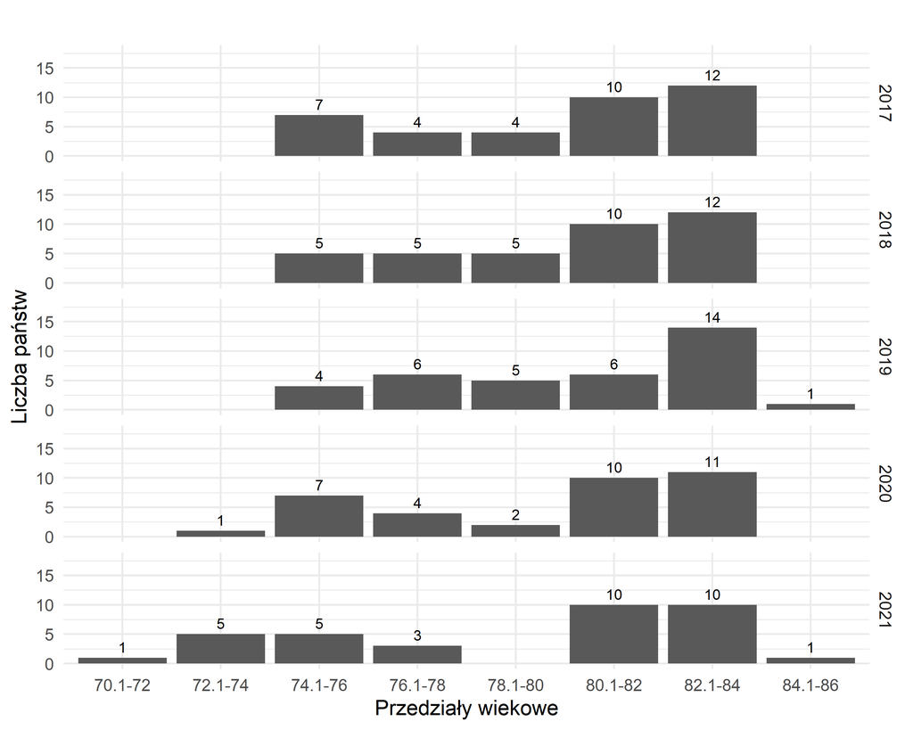

### Zbadajmy jeszcze wskaźniki:

#### Wartość najmniejsza, dolny kwartyl, mediana, średnia, górny kwartyl, wartość największa:

```
##    Min. 1st Qu.  Median    Mean 3rd Qu.    Max.
##    71.4    74.6    81.3    79.1    82.5    84.4
```

#### Wariancja:

```
## [1] 16.38649
```

#### Odchylenie standardowe:

```
## [1] 4.048022
```

#### Odchylenie przeciętne:

```
## [1] 2.81694
```

#### Zakres:

```
## [1] 71.4 84.4
```

#### Rozstęp kwartylowy:

```
## [1] 7.9
```

#### Moda:

[output not shown]

## **Punkt 3.2 - Liczba wystąpień poszczególnych średnich długości życia z podziałem na rok, płeć i państwo**

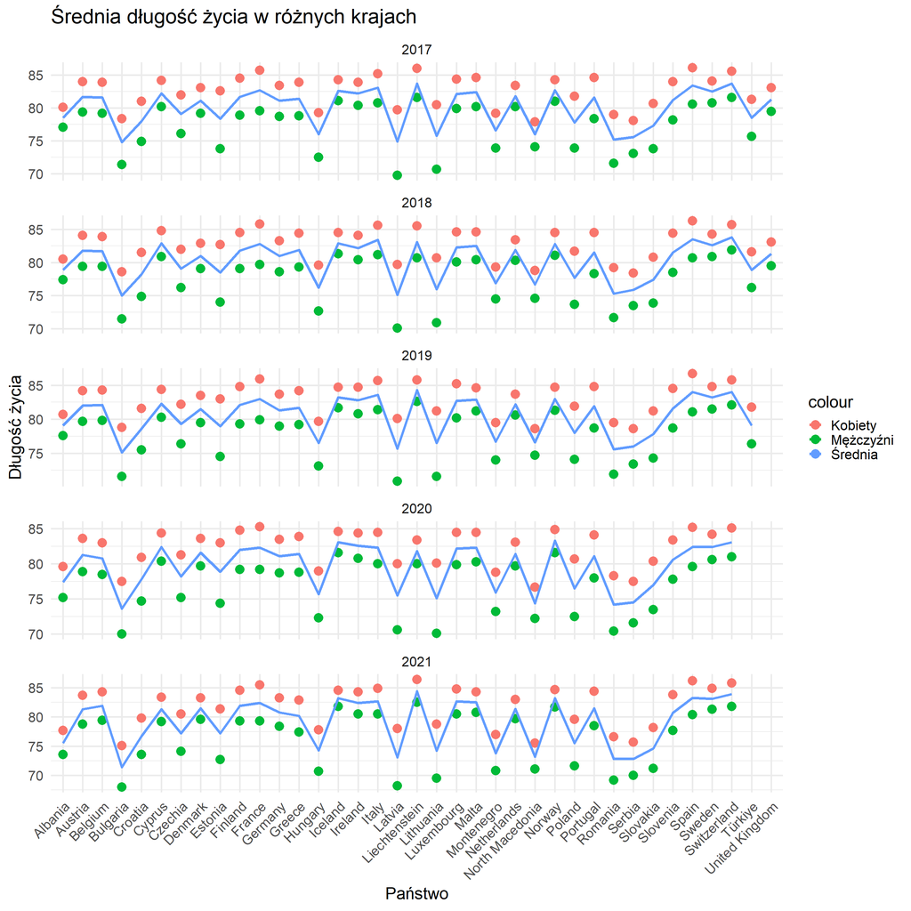

### Po dokładnym przeanalizowaniu tych wykresów możemy zaobserwować spadki średniej długości życia w niektórych państwach Europy. Najbardziej widoczne są zmiany na wykresie z roku 2020. Pandemia najmocniej poruszyła Liechtenstein, Północną Macedonię oraz Litwę.

### Na sam koniec zbadajmy wskaźniki:

#### Wartość najmniejsza, dolny kwartyl, mediana, średnia, górny kwartyl, wartość największa:

```
##    Min. 1st Qu.  Median    Mean 3rd Qu.    Max.
##   68.00   73.90   78.80   77.16   80.30   82.60
```

#### Wariancja:

```
## [1] 14.66578
```

#### Odchylenie standardowe:

```
## [1] 3.829593
```

#### Odchylenie przeciętne:

```
## [1] 3.40998
```

#### Zakres:

```
## [1] 68.0 82.6
```

#### Rozstęp kwartylowy:

```
## [1] 6.4
```

#### Moda:

```
## [1] 79.2
## attr(,"freq")
## [1] 6
```

# **Punkt 4 - Analiza zależności zmiennych**

## **Punkt 4.1 - Zmiana średniej długości życia na przestrzeni lat 2017-2021**

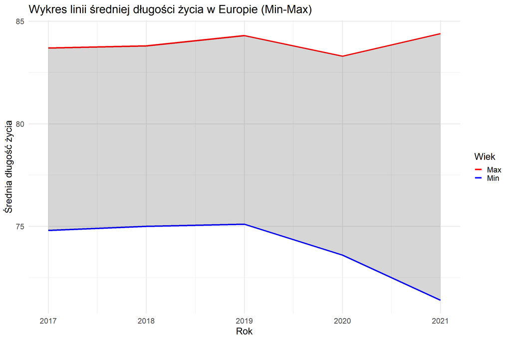

### Wniosek:

### Zauważyć możemy duży spadek wartości maksymalnej w 2020 roku, która odpowiada nam za największą średnią długość życia w Europie, oraz progresyjny spadek wartości minimalnej od roku 2019, odpowiadającej najmniejszej długości życia od roku 2019.

### Myśląc o podanych latach, nasuwa nam się od razu pandemia COVID-19. To ona musiała mieć wpływ na tak gwałtowne różnice w średnim wieku ludności Europy.

## **Punkt 4.2 - Wpływ epidemii COVID-19 na średnią długość życia w poszczególnych państwach (różnica między 2021 a 2019 rokiem)**

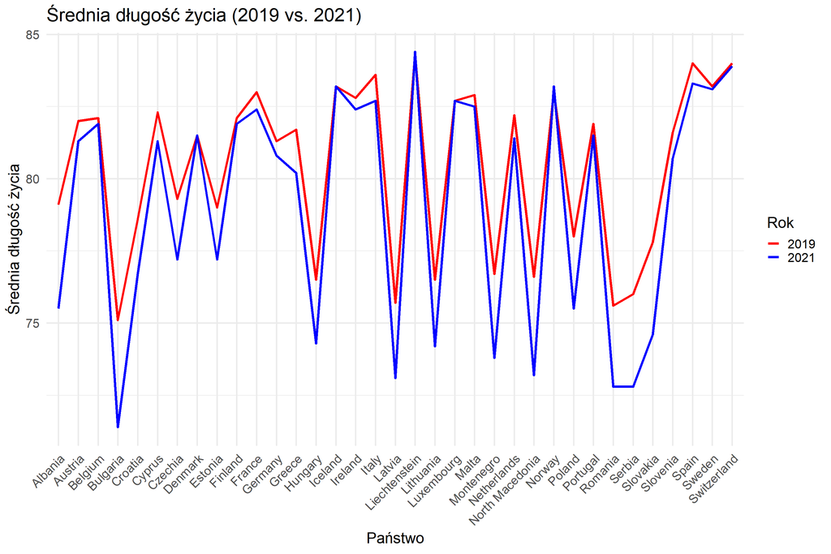

### Wniosek:

### Na tym wykresie możemy idealnie zaobserwować prawdziwe skutki epidemii. Bardzo mocno dotknęła długość życia obywateli Bułgarii, Rumunii, Serbii oraz Słowacji. Potwierdziło się moje założenie, że w ciągu ostatnich lat, największy wpływ na regresję średniej długości życia w Europie wpłynął COVID-19.

##### Róźnice w wymienionych wyżej państwach (w latach):

###### Bułgaria

```
## [1] -3.7
```

###### Rumunia

```
## [1] -2.8
```

###### Serbia

```
## [1] -3.2
```

###### Słowacja

```
## [1] -3.2
```

##### Test t-studenta dla par zależnych (obserwacja tych samych państw w latach 2019 i 2021):

```
##
##  Paired t-test
##
## data:  data_covid$DlugoscZycia2021 and data_covid$DlugoscZycia2019
## t = -6.3948, df = 34, p-value = 2.658e-07
## alternative hypothesis: true mean difference is not equal to 0
## 95 percent confidence interval:
##  -1.7809092 -0.9219479
## sample estimates:
## mean difference
##       -1.351429
```

##### Dzięki temu testowi możemy zauważyć, że średnia różnica długości życia w Europie między rokiem 2019 a 2021 wyniosła około -1.35 roku.

## **Punkt 4.3 - Zależność średniej długości życia w Europie w 2021 roku od płci**

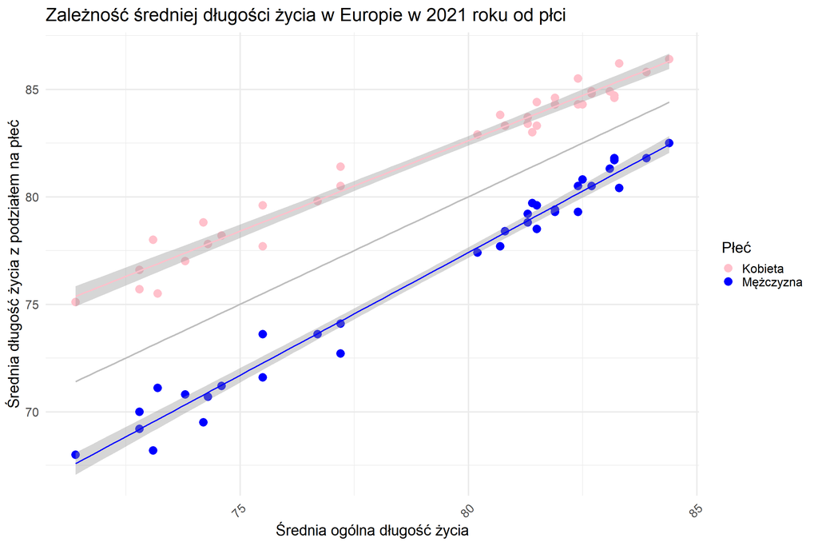

##### Przeprowadzimy test t-studenta dla par zależnych między długością życia mężczyzn a ogólną średnią długością życia.

```
##
##  Paired t-test
##
## data:  data_gender2021$Mezczyzni and data_gender2021$Ogolnie
## t = -17.999, df = 34, p-value < 2.2e-16
## alternative hypothesis: true mean difference is not equal to 0
## 95 percent confidence interval:
##  -3.027111 -2.412889
## sample estimates:
## mean difference
##           -2.72
```

##### Jak możemy zauważyć, średnia różnica długości życia mężczyzn różni się od średniej długości życia w Europie o -2.72 roku.

##### A teraz test t-studenta dla par zależnych między długością życia kobiet a ogólną średnią długością życia.

```
##
##  Paired t-test
##
## data:  data_gender2021$Kobiety and data_gender2021$Ogolnie
## t = 18.052, df = 34, p-value < 2.2e-16
## alternative hypothesis: true mean difference is not equal to 0
## 95 percent confidence interval:
##  2.439145 3.057998
## sample estimates:
## mean difference
##        2.748571
```

##### Jak możemy zauważyć, średnia różnica długości życia kobiet różni się od średniej długości życia w Europie o około +2.75 roku.

##### Aby potwierdzić jeszcze liniową zależność wykresów, wykonałem testy korelacji:

###### - Mężczyzn:

```
##
##  Pearson's product-moment correlation
##
## data:  data_gender2021$Ogolnie and data_gender2021$Mezczyzni
## t = 39.686, df = 33, p-value < 2.2e-16
## alternative hypothesis: true correlation is not equal to 0
## 95 percent confidence interval:
##  0.9794811 0.9948285
## sample estimates:
##       cor
## 0.9896856
```

###### - Kobiet:

```
##
##  Pearson's product-moment correlation
##
## data:  data_gender2021$Ogolnie and data_gender2021$Kobiety
## t = 31.706, df = 33, p-value < 2.2e-16
## alternative hypothesis: true correlation is not equal to 0
## 95 percent confidence interval:
##  0.9682195 0.9919559
## sample estimates:
##       cor
## 0.9839794
```

##### Wyniki testu potwierdzają, że zależność między dotychczasową średnią długością życia mężczyzn, a poszczególnymi punktami jest wręcz idealnie liniowa. Oszacowany współczynnik korelacji wynosi prawie 0.99, a 95% przedział ufności - od 0.979 do 0.994. Natomiast w przypadku kobiet współczynnik osiągnął wartość lekko ponad 0.98, przy również 95% przedziale ufności będącym od 0.968 do 0.991, zatem również jest to prawie liniowa zależność.

## **Punkt 4.4 - Regresja liniowa średniej długości życia mężczyzn w Europie w latach 2017-2021**

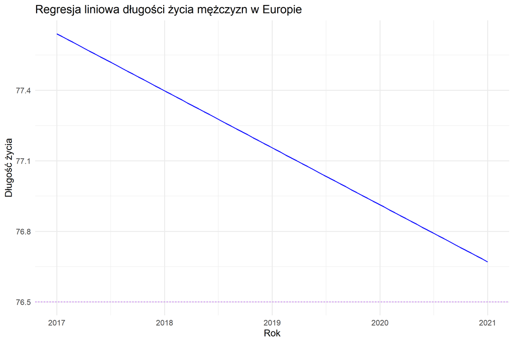

```
## as.numeric(Rok)
##      -0.2425714
```

##### Średni spadek długości życia mężczyzn na rok. Przy takiej wartości możemy zauważyć, że mniej więcej na początku 2022 roku, średnia długość życia mężczyzn w Europie wyniosła by już mniej niż 76.5 roku, a w 2024 roku byłoby to niecałe 76 lat. (Jestem szczerze ciekaw ile aktualnie wynosi, gdyż robię ten projekt w 2024 roku :D)

## **Punkt 4.5 - Regresja liniowa średniej długości życia kobiet w Europie w latach 2017-2021**

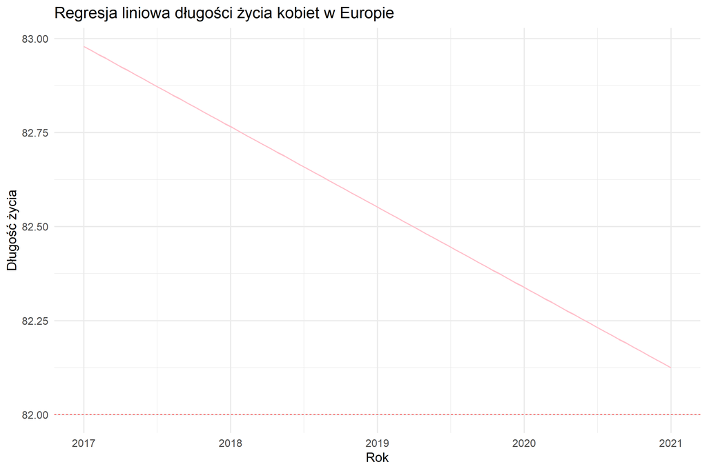

```
## as.numeric(Rok)
##      -0.2137143
```

# Punkt 5 - Podsumowanie

### Możemy dojść do konkluzji, że faktycznie pandemia COVID-19 miała duży wpływ na spadek średniej długości życia w Europie. Niestety dane, które są aktualnie dostępne, nie są wystarczające, aby stwierdzić, czy regresja będzie się utrzymywała przez następne lata.

### Dzięki użyciu środowiska R oraz nabytej wiedzy podczas całego przedmiotu “Rachunek prawdopodobieństwa i statystyka”, byłem w stanie odpowiedzieć na kilka nurtujących mnie od liceum pytań związanych z długością życia w Europie. Zyskałem także podstawową wiedzę z praktycznego używatkowania języka R do rozwiązywania problemów statystycznych.

### Wykorzystane biblioteki: DBI - łączenie się z bazą danych, knitr - dynamiczne generowanie raportów, rmarkdown - stworzenie całego notebooka, dplyr i tidyr - ułatwienie modyfikacji danych oraz pomoc w zachowaniu czystego i przejrzystego kodu, ggplot2 - rysowanie wykresów, DescTools - wykorzystany do wyliczania mody